# Week 5: Pandas!

## DSUA111: Data Science for Everyone, NYU, Fall 2020

### TA Jeff, `jpj251@nyu.edu`

- This slideshow: https://jjacobs.me/dsua111-sections/week-05
- All materials: https://github.com/jpowerj/dsua111-sections

## Outline

1. HW1 Review
2. Pandas!

## HW1 Review

The 4 most-missed questions (by far):

- q5b (~40% wrong)
- q7a (~35% wrong)
- q7c (~30% wrong)
- q7b (~25% wrong)

**(Q5B) What is it about selecting on the dependent variable here that limits our ability to draw inferences about the causal relationship between the independent variables and the outcome?**

A. There may other countries where people are happy, but which do not have easy access to the outdoors  
B. Happiness may be difficult to measure for some countries  
**---> C. We do not observe whether the factors common to the top performers might also be present in non-top performers**  
D. We must never draw causal conclusions from observational data

**A and B**: Unrelated to selecting on the independent variable (i.e., they are potential issues *whether or not the researcher selects on the independent variable)

**D** is just false. We should be *more careful* when drawing causal conclusions from observational data (relative to experimental data), but it's not this all-or-nothing. Sometimes experimental data is flawed to the point that we shouldn't draw causal conclusions from it, and sometimes observational data is good enough that we *should* draw causal conclusions after a careful analysis. (see, e.g., https://www.journals.uchicago.edu/doi/abs/10.1086/700936?mobileUi=0& )

## q7: Confounders

For all of these, PLEASE remember: $Z$ is a confounder if (and only if) it has a causal impact on **BOTH** the **independent** **AND** the **dependent** variable.

[figure not shown]

**(Q7A) On average, people who join the Marine Corps are less likely than those that don't to be diagnosed with cervical cancer. Before we recommend joining up as a preventive treatment, what's a likely confounder?**

A. Military health care plan  
B. Exposure to radiation in civilian life  
**---> C. Biological sex**  
D. Recruit training at Parris Island

[figure not shown]

**(Q7B) On average, people who can vote in New York City are more likely to support the US team in the World Cup than people who can't. Before we recommend sending out voting materials to improve support for the US soccer team, what is a likely confounder?**

A. Interest in soccer  
B. Living in NYC  
C. Age  
**---> D. US citizenship status**

[figure not shown]

**(Q7C) On average, people who eat dinner earlier in the day tend to be more at risk from flu. Before we suggest waiting until 11pm to ward off sickness, what is a likely confounder?**

A. Income  
B. Region of country  
**---> C. Age**  
D. Degree of danger in occupation

[figure not shown]

## Pandas

[figure not shown]

## Importing a Dataset

```python
gift_df = pd.read_csv("ForeignGifts_Universities.csv")
```

```
---------------------------------------------------------------------------
NameError                                 Traceback (most recent call last)
<ipython-input-1-42a862247680> in <module>
----> 1 gift_df = pd.read_csv("ForeignGifts_Universities.csv")

NameError: name 'pd' is not defined
```

What happened?

```python
import pandas as pd
```

```python
gift_df = pd.read_csv("ForeignGifts_Universities.csv")
```

## Inspecting a Dataset

```python
gift_df.head()
```

|  | ID | OPEID | Institution Name | City | State | Foreign Gift Received Date | Foreign Gift Amount | Gift Type | Country of Giftor | Giftor Name |
| --- | --- | --- | --- | --- | --- | --- | --- | --- | --- | --- |
| 0 | 1 | 107000 | Thunderbird School of Global Management | Glendale | AZ | 12/12/2012 | $1,220,000.00 | Contract | MEXICO | Instituto Technologico y de Estudio |
| 1 | 2 | 107000 | Thunderbird School of Global Management | Glendale | AZ | 11/26/2012 | $395,790.00 | Contract | CHINA | Intel Products (Chengdu) LTD |
| 2 | 3 | 107000 | Thunderbird School of Global Management | Glendale | AZ | 11/19/2012 | $2,769,651.00 | Contract | SAUDI ARABIA | Saudi Basic Industries Corporation |
| 3 | 4 | 107000 | Thunderbird School of Global Management | Glendale | AZ | 7/31/2012 | $364,128.00 | Contract | KUWAIT | Kuwait National Petroleum CO |
| 4 | 5 | 108100 | Arizona State University | Tempe | AZ | 12/29/2017 | $180,000.00 | Contract | THE NETHERLANDS | Airbus Group SE |

```python
gift_df['Institution Name'].value_counts()
```

```
University of California, Los Angeles                            3206
California Institute of Technology                               3127
Johns Hopkins University                                         1157
Columbia University in the City of New York                       791
Ohio State University (The)                                       681
                                                                 ...
University of North Texas Health Science Center at Fort Worth       1
Michigan Technological University                                   1
Villanova University                                                1
Colorado School of Mines                                            1
Hult International Business School                                  1
Name: Institution Name, Length: 150, dtype: int64
```

```python
nyu_df = gift_df[gift_df['Institution Name'] == "New York University"].copy()
nyu_df.head()
```

|  | ID | OPEID | Institution Name | City | State | Foreign Gift Received Date | Foreign Gift Amount | Gift Type | Country of Giftor | Giftor Name |
| --- | --- | --- | --- | --- | --- | --- | --- | --- | --- | --- |
| 14632 | 14633 | 278500 | New York University | New York | NY | 12/22/2017 | $350,000.00 | Monetary Gift | BERMUDA | Anonymous |
| 14633 | 14634 | 278500 | New York University | New York | NY | 12/15/2017 | $325,000.00 | Monetary Gift | HONG KONG | Anonymous |
| 14634 | 14635 | 278500 | New York University | New York | NY | 12/13/2017 | $1,000,000.00 | Monetary Gift | VIRGIN ISLANDS (BRITISH) | Anonymous |
| 14635 | 14636 | 278500 | New York University | New York | NY | 12/8/2017 | $1,000,000.00 | Monetary Gift | BRAZIL | Anonymous |
| 14636 | 14637 | 278500 | New York University | New York | NY | 11/15/2017 | $537,605.00 | Contract | THE NETHERLANDS | Government |

## Cleaning and Organizing a Dataset

```python
nyu_df['Foreign Gift Amount'] = nyu_df['Foreign Gift Amount'].str.replace("$","")
nyu_df['Foreign Gift Amount'] = nyu_df['Foreign Gift Amount'].str.replace(",","")
```

```python
nyu_df.head()
```

|  | ID | OPEID | Institution Name | City | State | Foreign Gift Received Date | Foreign Gift Amount | Gift Type | Country of Giftor | Giftor Name |
| --- | --- | --- | --- | --- | --- | --- | --- | --- | --- | --- |
| 14632 | 14633 | 278500 | New York University | New York | NY | 12/22/2017 | 350000.00 | Monetary Gift | BERMUDA | Anonymous |
| 14633 | 14634 | 278500 | New York University | New York | NY | 12/15/2017 | 325000.00 | Monetary Gift | HONG KONG | Anonymous |
| 14634 | 14635 | 278500 | New York University | New York | NY | 12/13/2017 | 1000000.00 | Monetary Gift | VIRGIN ISLANDS (BRITISH) | Anonymous |
| 14635 | 14636 | 278500 | New York University | New York | NY | 12/8/2017 | 1000000.00 | Monetary Gift | BRAZIL | Anonymous |
| 14636 | 14637 | 278500 | New York University | New York | NY | 11/15/2017 | 537605.00 | Contract | THE NETHERLANDS | Government |

```python
nyu_df['amount_numeric'] = nyu_df['Foreign Gift Amount'].astype('float')
```

```python
nyu_df.head()
```

|  | ID | OPEID | Institution Name | City | State | Foreign Gift Received Date | Foreign Gift Amount | Gift Type | Country of Giftor | Giftor Name | amount_numeric |
| --- | --- | --- | --- | --- | --- | --- | --- | --- | --- | --- | --- |
| 14632 | 14633 | 278500 | New York University | New York | NY | 12/22/2017 | 350000.00 | Monetary Gift | BERMUDA | Anonymous | 350000.0 |
| 14633 | 14634 | 278500 | New York University | New York | NY | 12/15/2017 | 325000.00 | Monetary Gift | HONG KONG | Anonymous | 325000.0 |
| 14634 | 14635 | 278500 | New York University | New York | NY | 12/13/2017 | 1000000.00 | Monetary Gift | VIRGIN ISLANDS (BRITISH) | Anonymous | 1000000.0 |
| 14635 | 14636 | 278500 | New York University | New York | NY | 12/8/2017 | 1000000.00 | Monetary Gift | BRAZIL | Anonymous | 1000000.0 |
| 14636 | 14637 | 278500 | New York University | New York | NY | 11/15/2017 | 537605.00 | Contract | THE NETHERLANDS | Government | 537605.0 |

```python
nyu_df.sort_values(by=['amount_numeric'], ascending=False, inplace=True)
nyu_df.head()
```

|  | ID | OPEID | Institution Name | City | State | Foreign Gift Received Date | Foreign Gift Amount | Gift Type | Country of Giftor | Giftor Name | amount_numeric |
| --- | --- | --- | --- | --- | --- | --- | --- | --- | --- | --- | --- |
| 14778 | 14779 | 278500 | New York University | New York | NY | 5/1/2013 | 21783526.00 | Contract | UNITED ARAB EMIRATES | Omeir Travel | 21783526.0 |
| 14645 | 14646 | 278500 | New York University | New York | NY | 7/31/2017 | 13369447.00 | Monetary Gift | SWITZERLAND | Anonymous | 13369447.0 |
| 14720 | 14721 | 278500 | New York University | New York | NY | 12/11/2014 | 9999973.00 | Monetary Gift | UNITED ARAB EMIRATES | Executive Authority of Abu Dhabi | 9999973.0 |
| 14702 | 14703 | 278500 | New York University | New York | NY | 1/11/2016 | 9516904.00 | Monetary Gift | CHINA | Anonymous | 9516904.0 |
| 14706 | 14707 | 278500 | New York University | New York | NY | 1/1/2016 | 8617263.00 | Contract | UNITED ARAB EMIRATES | Anonymous | 8617263.0 |

## Variable Types

```python
nyu_df.dtypes
```

```
ID                              int64
OPEID                           int64
Institution Name               object
City                           object
State                          object
Foreign Gift Received Date     object
Foreign Gift Amount            object
Gift Type                      object
Country of Giftor              object
Giftor Name                    object
amount_numeric                float64
dtype: object
```

## Measures of Frequency/Central Tendency

```python
nyu_df['amount_numeric'].mean()
```

```
1041806.82
```

## Measures of Dispersion/Position

```python
nyu_df['amount_numeric'].std()
```

```
2014429.729496327
```

## Visualization

```python
plt.hist(nyu_df['amount_numeric'])
plt.show()
```

```
---------------------------------------------------------------------------
NameError                                 Traceback (most recent call last)
<ipython-input-15-9ab9068df8a0> in <module>
----> 1 plt.hist(nyu_df['amount_numeric'])
      2 plt.show()

NameError: name 'plt' is not defined
```

What happened?

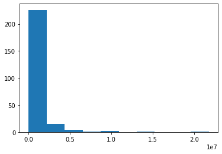

```python
import matplotlib.pyplot as plt
plt.hist(nyu_df['amount_numeric'])
plt.show()
```

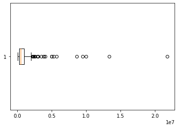

```python
plt.boxplot(nyu_df['amount_numeric'], vert=False)
plt.show()
```